# OM380.17 - MSBA: Assignment #2

### Forecasting Aggregate Electricity Generation in the US:

### Seasonal ARIMA Lab.

#### (Total 40 pts.)

#### Due: Nov. 20 (before 9:00am)

In this assignment we will focus on estimation of electricity generation in the US through December 2022. We will base our analysis on the monthly data (index) provided by the Federal Reserve in https://fred.stlouisfed.org/series/IPG2211N

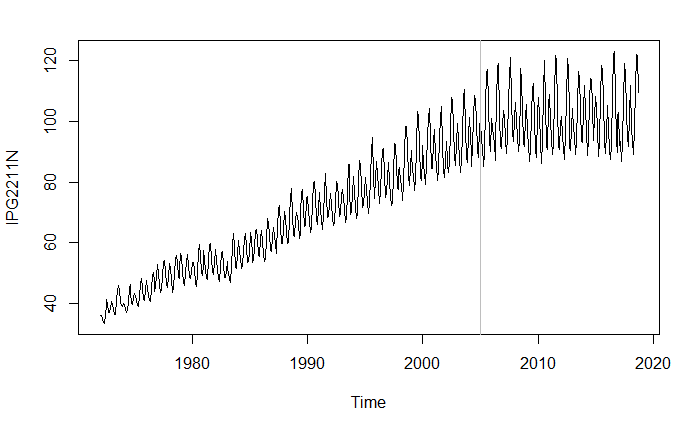

```r
library(fpp)
library(dplyr)

PG <- read.csv("IPG2211N.csv") %>%
  select(-DATE) %>%
  ts(start=c(1972,1), frequency=12)
plot(PG)
abline(v=c(2005,1), col="gray")
```

Initially we will set up as training data the series from January 1972 through December 1995, and the testing set as the data from January 1996 through December 2000. First we will analyze the data during the growth period. To maintain consistency across the class, please execute the following two command to generate the training and testing data sets as indicated:

```r
PG1.tr <- window(PG, end=c(1995,12))
PG1.te <- window(PG, start=c(1996,1), end=c(2000,12))
```

####1. (5 pts.) Preliminary analysis of training data: * Obtain the Box-Cox transformation parameter lambda for the training set PG1.tr

```r
L <- BoxCox.lambda(PG1.tr)
z <- BoxCox(PG1.tr,L)
par(mfrow=c(2,1))
plot(PG1.tr)
plot(z)
```

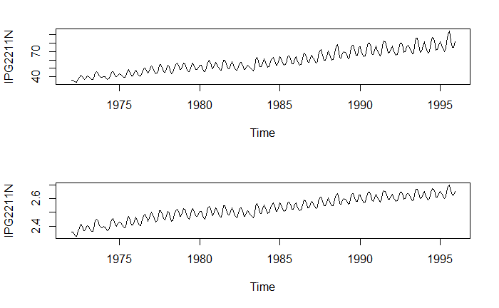

```r
par(mfrow=c(1,1))
```

```r
print("following is the best value of Lambda")
```

```
[1] "following is the best value of Lambda"
```

```r
print(L)
```

```
[1] -0.2530983
```

- Use the **ggtsdisplay(…, lag=48)** function to examine *ACF* and *PACF* of the Box-Cox transformed series with a non-seasonal difference. Do the differenced and transformed series look stationary?

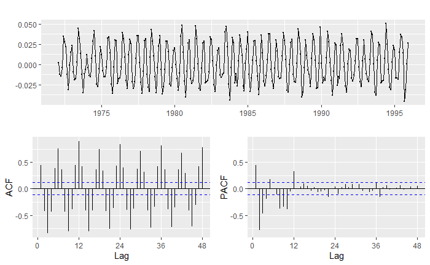

```r
#ggtsdisplay(z,lag = 48)
z %>% diff(1) %>% ggtsdisplay(lag=48)
```

The above series revolves around a constant mean but the variance is changing in seasonal patterns. Thus we can apply a seasonal difference (at lag = 12) to make it more stationary

Using the ADF test to check for stationary property

```r
d <- z %>% diff(1)
adf.test(d, alternative = 'stationary', k =12)
```

```
p-value smaller than printed p-value
```

```
    Augmented Dickey-Fuller Test

data:  d
Dickey-Fuller = -5.2335, Lag order = 12, p-value = 0.01
alternative hypothesis: stationary
```

The ADF test is showing it as stationary, but looking at the ACF and the series plot (which is not looking as a white noise) it does not seems that it is stationary

Also, we can see a spike at 36 => P would be 3; also q = 9 ; Q = 4 ; p=9

- Use the **ggtsdisplay(…, lag=48)** function to examine *ACF* and *PACF* of the Box-Cox transformed series with a seasonal difference. Do the differenced and transformed series look stationary?

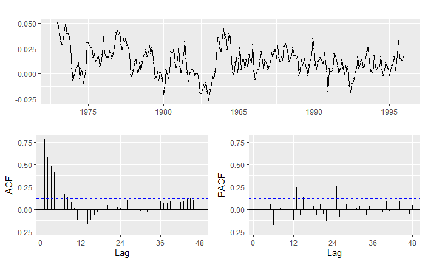

```r
z %>% diff(lag = 12) %>% ggtsdisplay(lag=48)
```

If at all we want to fit arima on this series, following would be the parameters:

p = 6; since if we go till 9, significant till 6; Similarly P = 2 ; q = 8 ; Q = 2

- Use the **ggtsdisplay(…, lag=48)** function to examine *ACF* and *PACF* of the Box-Cox transformed series with both a seasonal difference and a non-seasonal difference. Do the differenced and transformed series look stationary?

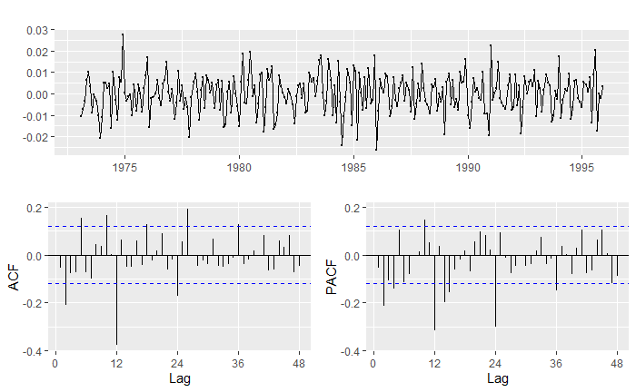

```r
z %>% diff(1) %>% diff(lag = 12) %>%  ggtsdisplay(lag=48)
```

This time series does looks stationary. It has a constant mean and also the variance is also not varying differently across different lags

p = 9 P = 3 q = 5 Q = 3

- Run the **adf.test(…)** on the above series. What do you conclude from the test?

```r
d <- z %>% diff(1) %>% diff(lag = 12)
adf.test(d, alternative = 'stationary', k =12)
```

```
p-value smaller than printed p-value
```

```
    Augmented Dickey-Fuller Test

data:  d
Dickey-Fuller = -5.9947, Lag order = 12, p-value = 0.01
alternative hypothesis: stationary
```

Since the p-value is less than 5 thus the time series is stationary

- If you were to fit an *ARIMA* model to each of the (three) differenced series you obtained above, what would be the maximum order of the $(p,d,q) (P,D,Q)_{12}$ model in each case? (i.e., what is the maximum values of $p,P,q$ and $Q$ for each of the value combinations of $d$ and $D$?) based on the models ACF and PACF plots above,

Case 1: P = 3; q = 9 ; Q = 4 ; p=9 ; d = 1 ; D = 0  
Case 2: p = 6; q = 8; P = 2; Q = 2; d = 0; D=1 Case 3: p = 9; q = 5; P = 3; Q = 3; d=1 ; D = 1

####2. (5 pts.) Automatic ARIMA model selection:

- Run the **auto.arima(…)** function to fit an ARIMA model on the Box-Cox transformation of the PG1.tr dataset, and report the order of the model, the value of the model parameters and the value of the AICc and BIC information criteria.

```r
q2 <- auto.arima(PG1.tr, lambda = L)
print("Following are the required values after fitting the auto arima")
```

```
[1] "Following are the required values after fitting the auto arima"
```

```r
summary(q2)
```

```
Series: PG1.tr
ARIMA(2,1,1)(0,1,1)[12]
Box Cox transformation: lambda= -0.2530983

Coefficients:
         ar1      ar2      ma1     sma1
      0.6187  -0.2491  -0.6813  -0.8008
s.e.  0.1150   0.0655   0.1096   0.0477

sigma^2 estimated as 4.918e-05:  log likelihood=970.21
AIC=-1930.42   AICc=-1930.19   BIC=-1912.33

Training set error measures:
                     ME     RMSE       MAE        MPE     MAPE     MASE       ACF1
Training set -0.0935554 1.176245 0.8729458 -0.1941531 1.476424 0.385567 -0.1173698
```

- Use the **checkresiduals(…)** function to assess the validity of the model you obtained in Question 1. Based on the results you obtained comment on the validity of the model.

```
    Ljung-Box test

data:  Residuals from ARIMA(2,1,1)(0,1,1)[12]
Q* = 29.262, df = 20, p-value = 0.08272

Model df: 4.   Total lags used: 24
```

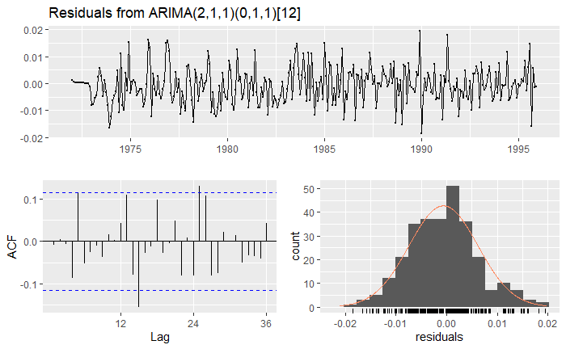

```r
checkresiduals(q2)
```

After checking the ljung values, we can say that the series is stationary. However, upon checking the ACF plot, there are still some lags above the range, indicating that the resultant residuals are not similar to white noise and there is still some information left

- Use the **forecast(…)** function to prepare a 60 month-ahead (5-year) forecast for the electricity generation and then overlay the actual data for electricity generation.

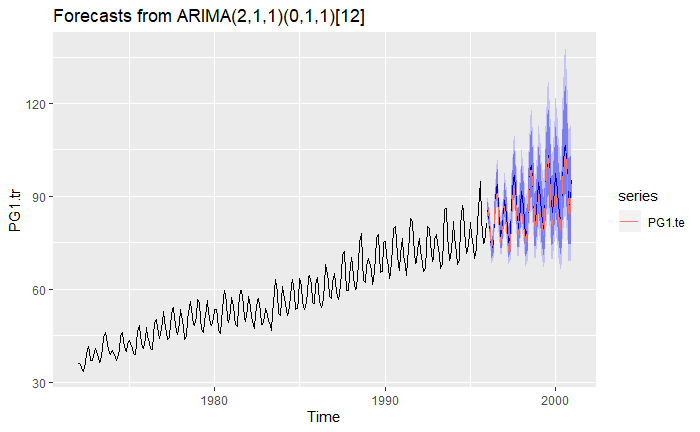

```r
q3 <- forecast(q2,h = 60)
autoplot(q3)+
autolayer(PG1.te)
```

```r
NA
NA
```

- Use the **accuracy(…)** function to obtain the training and testing fit (PG1.te) metrics for the model obtained. Based on the visual inspection of the forecast plot and the out-of-sample fit statistics comment on the forecast bias.

```r
accuracy(q3,PG1.te)
```

```
                     ME     RMSE       MAE        MPE     MAPE     MASE       ACF1 Theil's U
Training set -0.0935554 1.176245 0.8729458 -0.1941531 1.476424 0.385567 -0.1173698        NA
Test set     -2.2196194 3.047559 2.5506190 -2.6392460 3.028170 1.126570  0.5894791 0.4885983
```

The test statistic errors are fairly higher than the training set errors as we can see from the graph above as well. Thus the functional bias is high

####3. (5 pts.) Manual Model Selection on $(p,0,q) (P,1,Q)_{12}$:

- Search manually for a model on the seasonally differenced series to improve on the automatic selection in Question 2. To limit your manual search do not exceed the maximum values of $p,q,P$ and $Q$ that you identified in Question 1.

Ideally I would want to check for p -> 0:9, q-> 0:9, P-> 0:4 and similarly for Q. But it is becoming very much computationally heavy. Thus to make it computationally light, I will just be checking it with Auto Arima’s AIC value in the previous question, since you will be missing one data point.

```r
## Trying different parameters for p,q,P and Q :

## Using grid search to calculate the training AICc, BIC and AIC. Also, looking for RMSE, MAPE, MASE in the test set

##

pval <- c(0:9)
qval <- c(0:9)
Qval <- c(0:4)
Pval <- c(0:4)
frcst_arry <- data.frame()
counter <- 0
aicflag <- 0

for(i in 1:9){
  #print(pval[i])
  for(j in 1:9 ){

    for(k in 1:5){
      for(l in 1:5){
      counter = counter+1
      #print(counter)
      tryCatch({

      p <- pval[i]
      q <- qval[j]
      Q <- Qval[k]
      P <- Pval[l]
      train <- PG1.tr %>% Arima(order= c(p,0,q), seasonal= c(P,1,Q), lambda = L)
      trainAic <- train$aic
      trainBic <- train$bic

      if(trainAic < q2$aic & trainBic < q2$bic )
      {
      print("test")
      aicflag <- trainAic
      trainAICc <- train$aicc
      trainBIC <- train$bic
      forecast_train <- forecast(train,h=60)

      forecast_train_summ <- accuracy(forecast_train,PG1.te)

      train_mape <- forecast_train_summ[2,5]
      train_mase <- forecast_train_summ[2,6]

      frcst_arry <- rbind(frcst_arry,c(trainAic,trainAICc,trainBIC,train_mape,train_mase,p[1],0,q[1],P[1],1,Q[1]))
      break
      }

      }, error = function(e){ })
                next


      }
      if(trainAic < q2$aic & trainBic < q2$bic )
      {
      break
      }

    }
     if(trainAic < q2$aic & trainBic < q2$bic )
      {
      break
      }

  }
   if(trainAic < q2$aic & trainBic < q2$bic )
      {
      break
      }
}
```

```
NA
```

The Above code was computationally expensive. Now checking for MASE wrt to Auto Arima

```r
## Trying different parameters for p,q,P and Q :

## Using grid search to calculate the training AICc, BIC and AIC. Also, looking for RMSE, MAPE, MASE in the test set

##

pval <- c(0:9)
qval <- c(0:9)
Qval <- c(0:4)
Pval <- c(0:4)
frcst_arry <- data.frame()
counter <- 0
aicflag <- 0
mapeauto <- accuracy(q3,PG1.te)
mapeauto <- mapeauto[2,5]

for(i in 1:9){
  #print(pval[i])
  for(j in 1:9 ){

    for(k in 1:5){
      for(l in 1:5){
      counter = counter+1
      #print(counter)
      tryCatch({

      p <- pval[i]
      q <- qval[j]
      Q <- Qval[k]
      P <- Pval[l]
      train <- PG1.tr %>% Arima(order= c(p,0,q), seasonal= c(P,1,Q), lambda = L)
      trainAic <- train$aic

      #print(trainAic)
      aicflag <- trainAic
      trainAICc <- train$aicc
      trainBIC <- train$bic
      forecast_train <- forecast(train,h=60)

      forecast_train_summ <- accuracy(forecast_train,PG1.te)

      train_mape <- forecast_train_summ[2,5]
      train_mase <- forecast_train_summ[2,6]
      #print(train_mape)

      if(train_mape < mapeauto)
      {
      print("test")
      frcst_arry <- rbind(frcst_arry,c(trainAic,trainAICc,trainBIC,train_mape,train_mase,p[1],0,q[1],P[1],1,Q[1]))

      break
      }

      }, error = function(e){ })
                next


      }
      if(train_mape < mapeauto)
      {
      #print("test")
      #frcst_arry <- rbind(frcst_arry,c(trainAic,trainAICc,trainBIC,train_mape,train_mase,p[1],0,q[1],P[1],1,Q[1]))
      break
      }

    }
     if(train_mape < mapeauto)
      {
      #print("test")
      #frcst_arry <- rbind(frcst_arry,c(trainAic,trainAICc,trainBIC,train_mape,train_mase,p[1],0,q[1],P[1],1,Q[1]))
      break
      }

  }
   if(train_mape < mapeauto)
      {
      #print("test")
      #frcst_arry <- rbind(frcst_arry,c(trainAic,trainAICc,trainBIC,train_mape,train_mase,p[1],0,q[1],P[1],1,Q[1]))
      break
      }
}
```

```
[1] "test"
```

```r
colnames(frcst_arry) <- c("AIC","AICc","BIC","MAPE","MASE","pvalue","dvalue","qvalue","Pvalue","Dvalue","Qvalue")
#qval <- [0,1]
#Pval <- [0]

print("Following are the various values for differenet parameters of p,q,P,Q \n")
```

```
[1] "Following are the various values for differenet parameters of p,q,P,Q \n"
```

```r
print(frcst_arry)
```

| AIC | AICc | BIC | MAPE | MASE | pvalue | dvalue | qvalue | Pvalue | Dvalue | Qvalue |
| --- | --- | --- | --- | --- | --- | --- | --- | --- | --- | --- |
| -1515.099 | -1514.952 | -1500.618 | 2.866771 | 1.116002 | 0 | 0 | 0 | 3 | 1 | 0 |

```r
NA
```

Checking for some models based on the table above

```r
## Trying different parameters for p,q,P and Q :

## Using grid search to calculate the training AICc, BIC and AIC. Also, looking for RMSE, MAPE, MASE in the test set

## Case 1

pval <- c(0:9)
qval <- c(0)
Qval <- c(0)
Pval <- c(0:4)
frcst_arry <- data.frame()
counter <- 0
aicflag <- 0
#mapeauto <- accuracy(q3,PG1.te)
#mapeauto <- mapeauto[2,5]

for(i in 1:9){
  #print(pval[i])
  #for(j in 1:2 ){

    #for(k in 1:4){
      for(l in 1:4){
      counter = counter+1
      #print(counter)
      tryCatch({

      p <- pval[i]
      q <- qval[1]
      Q <- Qval[1]
      P <- Pval[l]
      train <- PG1.tr %>% Arima(order= c(p,0,q), seasonal= c(P,1,Q), lambda = L)
      trainAic <- train$aic

      #print(trainAic)
      aicflag <- trainAic
      trainAICc <- train$aicc
      trainBIC <- train$bic
      forecast_train <- forecast(train,h=60)

      forecast_train_summ <- accuracy(forecast_train,PG1.te)

      train_mape <- forecast_train_summ[2,5]
      train_mase <- forecast_train_summ[2,6]
      #print(train_mape)

      frcst_arry5 <- rbind(frcst_arry5,c(trainAic,trainAICc,trainBIC,train_mape,train_mase,p[1],0,q[1],P[1],1,Q[1]))


      }, error = function(e){ })
                next


      }


    #}

 # }

}

colnames(frcst_arry5) <- c("AIC","AICc","BIC","MAPE","MASE","pvalue","dvalue","qvalue","Pvalue","Dvalue","Qvalue")
#qval <- [0,1]
#Pval <- [0]

print("Following are the various values for differenet parameters of p,q,P,Q \n")
```

```
[1] "Following are the various values for differenet parameters of p,q,P,Q \n"
```

```r
print(frcst_arry5)
```

[output not shown]

[output cut: 118 more lines]

```r
NA
```

Checking the models further

```
    Ljung-Box test

data:  Residuals from ARIMA(1,0,1)(3,1,3)[12]
Q* = 55.643, df = 16, p-value = 2.787e-06

Model df: 8.   Total lags used: 24


    Ljung-Box test

data:  Residuals from ARIMA(1,0,1)(3,1,3)[12]
Q* = 55.643, df = 16, p-value = 2.787e-06
```

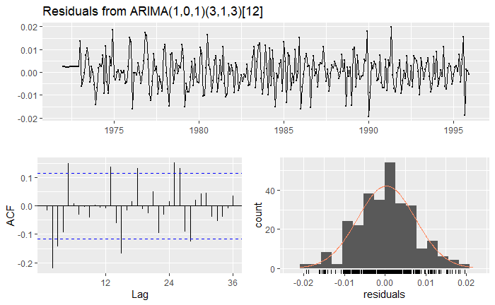

```r
test<- PG1.tr %>%
       Arima(order=c(1,0,1), seasonal=c(3,1,3), lambda = L)

print(checkresiduals(test))
```

```r
forecast_test <- forecast(test, h= 60)
print(accuracy(forecast_test,PG1.te))
```

```
                     ME     RMSE       MAE        MPE     MAPE      MASE        ACF1 Theil's U
Training set 0.03204974 1.224401 0.9188284 0.07019754 1.552606 0.4058326 -0.09639802        NA
Test set     1.12812218 2.790084 2.2715776 1.20010435 2.596765 1.0033215  0.73591071 0.4315849
```

- Report on the best model that you identified in each case and comment on its *AIC*, *AICc* and *BIC*. How do your model compares with the one found by **auto.arima(…)**? Model selected : (1,0,1)(3,1,3) AIC=-1906.53 AICc=-1905.85 BIC=-1873.94

As compared to Auto Arima, the MASE and MAPE are coming out to be lower, but it is failing the Ljung test, stating that the series is still not sationary. Since, d is fixed to 0 , the p value will be low

####4. (5 pts.) Manual Model Selection on $(p,1,q) (P,0,Q)_{12}$:

- Search manually for a model on the once-differenced series to improve on the automatic selection in Question 2. To limit your manual search do not exceed the maximum values of $p,q,P$ and $Q$ that you identified in Question 1.

```r
## Using grid search to calculate the training AICc, BIC and AIC. Also, looking for RMSE, MAPE, MASE in the test set

pval <- c(0,1,2,3)
qval <- c(0,1,2,3)
Qval <- c(0,1)
Pval <- c(0,1)
frcst_arry2 <- data.frame()

for(i in 1:4){
  #print(pval[i])
  for(j in 1:4 ){

    for(k in 1:2){
      for( l in 1:2)
      p <- pval[i]
      q <- qval[j]
      Q <- Qval[k]
      P <- Pval[l]
      train <- PG1.tr %>% Arima(order= c(p,1,q), seasonal= c(P,0,Q), lambda = L)
      trainAic <- train$aic

      trainAICc <- train$aicc
      trainBIC <- train$bic
      forecast_train <- forecast(train,h=60)

      forecast_train_summ <- accuracy(forecast_train,PG1.te)

      train_mape <- forecast_train_summ[2,5]
      train_mase <- forecast_train_summ[2,6]

      frcst_arry2 <- rbind(frcst_arry2,c(trainAic,trainAICc,trainBIC,train_mape,train_mase,p[1],1,q[1],P[1],0,Q[1]))



    }

  }
}

colnames(frcst_arry2) <- c("AIC","AICc","BIC","MAPE","MASE","pvalue","dvalue","qvalue","Pvalue","Dvalue","Qvalue")
#qval <- [0,1]
#Pval <- [0]



print("Following are the various values for differenet parameters of p,q,P,Q \n")
```

```
[1] "Following are the various values for differenet parameters of p,q,P,Q \n"
```

```r
print(frcst_arry2)
```

| AIC | AICc | BIC | MAPE | MASE | pvalue | dvalue | qvalue | Pvalue | Dvalue | Qvalue |
| --- | --- | --- | --- | --- | --- | --- | --- | --- | --- | --- |
| -2136.881 | -2136.838 | -2129.562 | 6.809403 | 2.5499534 | 0 | 1 | 0 | 1 | 0 | 0 |
| -2228.656 | -2228.571 | -2217.678 | 2.721559 | 1.0113340 | 0 | 1 | 0 | 1 | 0 | 1 |
| -2134.987 | -2134.902 | -2124.008 | 6.733892 | 2.5223802 | 0 | 1 | 1 | 1 | 0 | 0 |
| -2227.109 | -2226.967 | -2212.471 | 2.738871 | 1.0177714 | 0 | 1 | 1 | 1 | 0 | 1 |
| -2155.445 | -2155.303 | -2140.807 | 6.256574 | 2.3267724 | 0 | 1 | 2 | 1 | 0 | 0 |
| -2249.756 | -2249.542 | -2231.459 | 3.063266 | 1.1408596 | 0 | 1 | 2 | 1 | 0 | 1 |
| -2155.497 | -2155.284 | -2137.200 | 5.628323 | 2.0806252 | 0 | 1 | 3 | 1 | 0 | 0 |
| -2253.295 | -2252.995 | -2231.338 | 2.895704 | 1.0766091 | 0 | 1 | 3 | 1 | 0 | 1 |
| -2134.936 | -2134.851 | -2123.958 | 6.769088 | 2.5351846 | 1 | 1 | 0 | 1 | 0 | 0 |
| -2226.893 | -2226.751 | -2212.255 | 2.727646 | 1.0135546 | 1 | 1 | 0 | 1 | 0 | 1 |

[output cut: 22 more lines]

```r
NA
NA
```

Checking some models based on the table above

```
    Ljung-Box test

data:  Residuals from ARIMA(3,1,2)(1,0,1)[12]
Q* = 30.133, df = 17, p-value = 0.0254

Model df: 7.   Total lags used: 24


    Ljung-Box test

data:  Residuals from ARIMA(3,1,2)(1,0,1)[12]
Q* = 30.133, df = 17, p-value = 0.0254
```

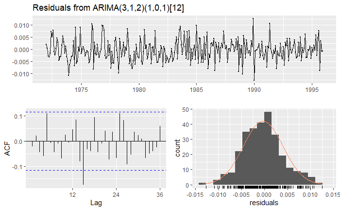

```r
test<- PG1.tr %>%
       Arima(order=c(3,1,2), seasonal=c(1,0,1), lambda = L)

print(checkresiduals(test))
```

```r
forecast_test <- forecast(test, h= 60)
print(accuracy(forecast_test,PG1.te))
```

```
                      ME     RMSE       MAE        MPE     MAPE      MASE       ACF1 Theil's U
Training set -0.07418552 1.175153 0.8742512 -0.1483273 1.491686 0.3861435 -0.1484183        NA
Test set     -2.19608646 3.028071 2.5334123 -2.6104378 3.006933 1.1189699  0.5855564 0.4854327
```

- Report on the best model that you identified in each case and comment on its *AIC*, *AICc* and *BIC*. How do your model compares with the ones found in Questions 2 and 3?

####5. (5 pts.) ARIMA model for the expanded training set:

- No we redefine the training and testing sets as follows:

```r
PG2.tr <- window(PG, end=c(2011,12))
```

- Obtain the Box-Cox transformation parameter lambda for the training set **PG2.tr**

```r
L <- BoxCox.lambda(PG2.tr)
z <- BoxCox(PG2.tr,L)
par(mfrow=c(2,1))
plot(PG2.tr)
plot(z)
```

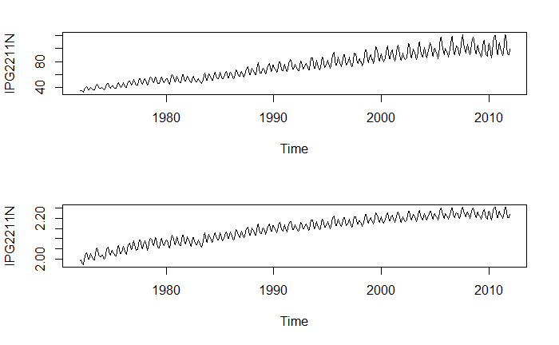

```r
par(mfrow=c(1,1))
```

```r
print("following is the best value of Lambda")
```

```
[1] "following is the best value of Lambda"
```

```r
print(L)
```

```
[1] -0.367202
```

- Difference the transformed series once at the seasonal and non-seasonal levels (i.e.,$d=1$ and $D=1$) and run the **adf.test(…)** on the resulting series. What do you conclude from the test?

```r
d <- z %>% diff(1) %>% diff(lag = 12)
adf.test(d, alternative = 'stationary', k =12)
```

```
p-value smaller than printed p-value
```

```
    Augmented Dickey-Fuller Test

data:  d
Dickey-Fuller = -8.0736, Lag order = 12, p-value = 0.01
alternative hypothesis: stationary
```

Since the value is still less than 0.05, the null hypothesis is rejected, thus the resultant series is stationary

- If you were to fit an ARIMA model to the time series you obtained above, what would be the maximum order of the $(p,1,q) (P,1,Q)_{12}$ model? (i.e., what is the maximum values of $p,P,q$ and $Q$? )

Checking the ACF and PACF plots of the series (p,1,q)(P,1,Q)[12]

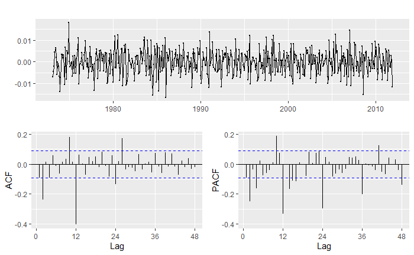

```r
z %>% diff(1) %>% diff(lag = 12) %>% ggtsdisplay(lag=48)
```

```r
NA
NA
```

Here in the PACF plot , we can see the seasonal lags are varying till 48 lags => P = 4; Similarly , p = 9 Looking at the ACF plots: q = 9 Q = 2

####6. (5 pts.) Automatic ARIMA model selection on the expanded dataset:

- Run the **auto.arima(…)** function to fit an *ARIMA* model on the Box-Cox transformation of the **PG2.tr** dataset, and report the order of the model, the value of the model parameters and the value of the *AIC*, *AICc* and *BIC*?

```r
q6 <- auto.arima(PG2.tr, lambda = L)
print("Following are the required values after fitting the auto arima")
```

```
[1] "Following are the required values after fitting the auto arima"
```

```r
summary(q6)
```

```
Series: PG2.tr
ARIMA(1,1,3)(0,1,1)[12]
Box Cox transformation: lambda= -0.367202

Coefficients:
         ar1      ma1      ma2     ma3     sma1
      0.4588  -0.5969  -0.2423  0.0614  -0.7836
s.e.  0.3294   0.3317   0.0741  0.1345   0.0318

sigma^2 estimated as 1.798e-05:  log likelihood=1886.56
AIC=-3761.13   AICc=-3760.95   BIC=-3736.25

Training set error measures:
                     ME     RMSE      MAE        MPE     MAPE      MASE       ACF1
Training set -0.1266131 1.567936 1.147096 -0.2094499 1.544572 0.4612656 -0.1131731
```

- Execute the residual diagnostics and comment on the validity of the model.

```r
print("following are the residuals ")
```

```
[1] "following are the residuals "
```

```
    Ljung-Box test

data:  Residuals from ARIMA(1,1,3)(0,1,1)[12]
Q* = 31.946, df = 19, p-value = 0.03169

Model df: 5.   Total lags used: 24


    Ljung-Box test

data:  Residuals from ARIMA(1,1,3)(0,1,1)[12]
Q* = 31.946, df = 19, p-value = 0.03169
```

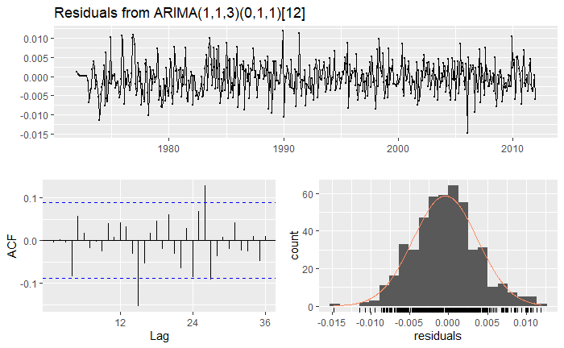

```r
print(checkresiduals(q6))
```

Since the p value in Ljung box is less than 0.05, the resultant model is not stationary. Also, the ACF plots of residuals suggests that there is some information which is still not captured by the model

####7. (5 pts.) Automatic ARIMA model selection with a reduced training dataset:

- As the patterns of consumption and generation changed substantially on 2005, before setting on a forecasting model we will try reducing the training set to information posterior to 2005. To this end we define the training data set as follows:

```r
PG3.tr <- window(PG, start=c(2005,1), end=c(2011,12))
PG3.te <- window(PG, start=c(2012,1), end=c(2017,12))
```

- Now run the **auto.arima(…)** function to fit a model on the **PG3.tr** dataset, and report the order of the model, the value of the model parameters, and the values of *AIC*, *AICc* and *BIC*.

```r
q7 <- auto.arima(PG3.tr)
print("Following are the required values after fitting the auto arima")
```

```
[1] "Following are the required values after fitting the auto arima"
```

```r
summary(q7)
```

```
Series: PG3.tr
ARIMA(0,0,1)(2,1,1)[12]

Coefficients:
         ma1     sar1     sar2     sma1
      0.6702  -0.0635  -0.2438  -0.6571
s.e.  0.0868   0.3035   0.1998   0.3845

sigma^2 estimated as 5.392:  log likelihood=-166.8
AIC=343.61   AICc=344.52   BIC=354.99

Training set error measures:
                    ME     RMSE      MAE      MPE     MAPE      MASE       ACF1
Training set 0.3704143 2.089163 1.584466 0.339566 1.554297 0.5672604 0.06623551
```

- Diagnose the model’s residuals to assess the validity of the model you obtained above. Based on the results you obtained comment on the validity of the model.

```r
print("following are the residuals ")
```

```
[1] "following are the residuals "
```

```
    Ljung-Box test

data:  Residuals from ARIMA(0,0,1)(2,1,1)[12]
Q* = 15.21, df = 13, p-value = 0.2944

Model df: 4.   Total lags used: 17


    Ljung-Box test

data:  Residuals from ARIMA(0,0,1)(2,1,1)[12]
Q* = 15.21, df = 13, p-value = 0.2944
```

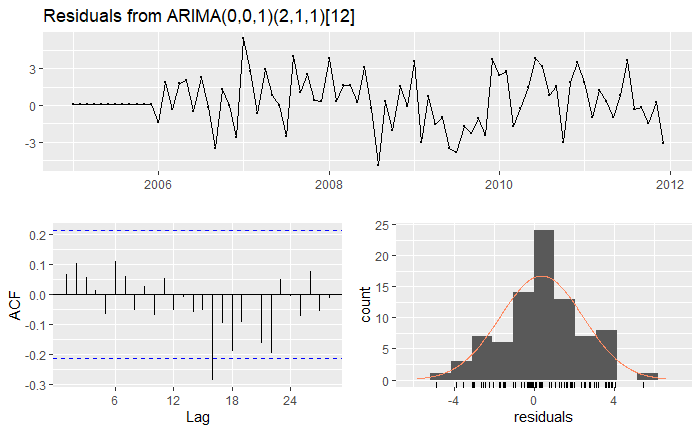

```r
print(checkresiduals(q7))
```

By looking at the p-value and the plot, it seems that the model is stationary and giving good results

- Using the **PG3.tr** dataset, try to get a better model than the one obtained by the **auto.arima(…)** function, possibly changing also the number of differences. Use the information criteria and the validity of the model to select the best model.

Checking the ACF and PACF plots to get an idea about the values of p,q,P,Q :

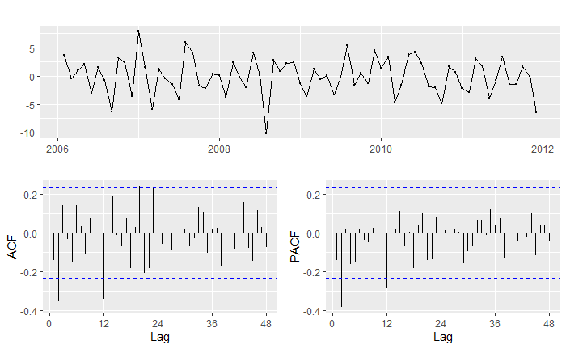

```r
PG3.tr  %>% diff(1) %>% diff(lag = 12) %>% ggtsdisplay(lag=48)
```

```r
NA
NA
```

By checking PACF, maximum value of p : 2 maximum value of P : 2 maximum value of q : 2 maximum value of Q : 2

```r
## Using grid search to calculate the training AICc, BIC and AIC. Also, looking for RMSE, MAPE, MASE in the test set

pval <- c(0,1,2)
qval <- c(0,1,2)
Qval <- c(0,1,2)
Pval <- c(0,1,2)
dval <- c(0,1,2)
Dval <- c(0,1,2)

frcst_arry7 <- data.frame()
counter = 0
for(i in 1:3){
  #print(pval[i])
  for(j in 1:3 ){
    for(k in 1:2){
      for(l in 1:2){
          for(n in 1:3){
            for(o in 1:3){

                p <- pval[i]
                q <- qval[j]
                Q <- Qval[k]
                P <- Pval[l]
                d <- dval[n]
                D <- Dval[o]
                counter = counter +1



                  tryCatch({
                  train <-  PG3.tr %>% Arima(order= c(p,d,q), seasonal= c(P,D,Q))
                  #train <-  PG3.tr %>% Arima(order= c(p,d,q), seasonal= c(P,D,Q))


                trainAic <- train$aic
                trainAICc <- train$aicc
                trainBIC <- train$bic
                forecast_train <- forecast(train,h=60)
                forecast_train_summ <- accuracy(forecast_train,PG3.te)
                train_mape <- forecast_train_summ[2,5]
                train_mase <- forecast_train_summ[2,6]

                frcst_arry7 <- rbind(frcst_arry7,c(trainAic,trainAICc,trainBIC,train_mape,train_mase,p[1],d[1],q[1],P[1],D[1],Q[1]))
                  }, error = function(e){ })
                next

            }
          }
        }
      }
    }
  }


colnames(frcst_arry7) <- c("AIC","AICc","BIC","MAPE","MASE","pvalue","dvalue","qvalue","Pvalue","Dvalue","Qvalue")
#qval <- [0,1]
#Pval <- [0]



print("Following are the various values for differenet parameters of p,q,P,Q \n")
```

```
[1] "Following are the various values for differenet parameters of p,q,P,Q \n"
```

```r
print(frcst_arry7)
```

| AIC | AICc | BIC | MAPE | MASE | pvalue | dvalue | qvalue | Pvalue | Dvalue | Qvalue |
| --- | --- | --- | --- | --- | --- | --- | --- | --- | --- | --- |
| 625.1874 | 625.3356 | 630.0491 | 8.093495 | 2.9688245 | 0 | 0 | 0 | 0 | 0 | 0 |
| 386.7035 | 386.7606 | 388.9802 | 2.346188 | 0.8665062 | 0 | 0 | 0 | 0 | 1 | 0 |
| 389.8813 | 389.9502 | 391.9756 | 6.137041 | 2.2241843 | 0 | 0 | 0 | 0 | 2 | 0 |
| 598.3166 | 598.3660 | 600.7354 | 7.988190 | 2.9688245 | 0 | 1 | 0 | 0 | 0 | 0 |
| 370.1760 | 370.2339 | 372.4386 | 18.674239 | 6.7154215 | 0 | 1 | 0 | 0 | 1 | 0 |
| 376.2635 | 376.3337 | 378.3411 | 67.519906 | 24.3661608 | 0 | 1 | 0 | 0 | 2 | 0 |
| 600.0125 | 600.0625 | 602.4192 | 259.164216 | 93.1658220 | 0 | 2 | 0 | 0 | 0 | 0 |
| 427.2652 | 427.3240 | 429.5137 | 457.274942 | 164.9465584 | 0 | 2 | 0 | 0 | 1 | 0 |
| 410.7817 | 410.8532 | 412.8422 | 1002.438919 | 361.6598487 | 0 | 2 | 0 | 0 | 2 | 0 |
| 478.5994 | 478.8994 | 485.8918 | 2.397837 | 0.8746850 | 0 | 0 | 0 | 1 | 0 | 0 |

[output cut: 299 more lines]

```r
NA
NA
```

Checking further for different values

```r
test<- PG3.tr %>%
       Arima(order=c(0,1,2), seasonal=c(1,2,1))

print(checkresiduals(test))
forecast_test <- forecast(test, h= 72)
print(accuracy(forecast_test,PG3.te))
```

[output not shown]

Based on the values above, selecting (0,1,2)(1,2,1)

- For the best model found thus far, prepare a 72 month-ahead forecast for the electricity generation and then overlay the actual data for electricity generation.

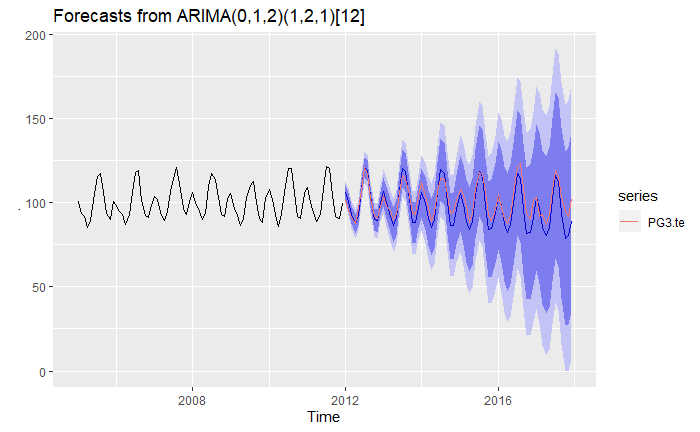

```r
forecast_train <- forecast(test,h=72)
autoplot(forecast_train)+
autolayer(PG3.te)
```

```r
print("Following are the accuracies of the model ")
```

```
[1] "Following are the accuracies of the model "
```

```r
print(accuracy(forecast_train,PG3.te))
```

```
                     ME     RMSE      MAE        MPE     MAPE      MASE        ACF1 Theil's U
Training set -0.1884221 2.460786 1.640394 -0.2320634 1.601741 0.5872833 -0.02015451        NA
Test set      3.4525285 5.841371 4.785205  3.5410977 4.815570 1.7131683  0.63548221 0.6736739
```

- Based on the visual inspection of the forecast plot and the out-of-sample fit statistics comment on the forecast bias.

Based on the plot and the accuracy table, the forecast bias of the model is fairly high

####8. (5 pts) Forecasting future monthly US electricity generation:

- Now define the training and testing data set as:

```r
PG.tr <- window(PG, start=c(2005,1), end=c(2017,12))
PG.te <- window(PG, start=c(2018,1))
```

- Use the **Arima(…)** function to fit the best model you have found thus far on PG.tr, run the model diagnostics to test the model validity and use it to extrapolate (forecast) the monthly generation of electricity in the US through the end of 2022 (i.e., forecast 60 months ahead).

Checking the residuals on the time series

```r
train8 <-  PG.tr %>% Arima(order= c(3,1,2), seasonal= c(1,0,1))
print("following are the residuals from the given model")
```

```
[1] "following are the residuals from the given model"
```

```
    Ljung-Box test

data:  Residuals from ARIMA(3,1,2)(1,0,1)[12]
Q* = 29.729, df = 17, p-value = 0.02837

Model df: 7.   Total lags used: 24


    Ljung-Box test

data:  Residuals from ARIMA(3,1,2)(1,0,1)[12]
Q* = 29.729, df = 17, p-value = 0.02837
```

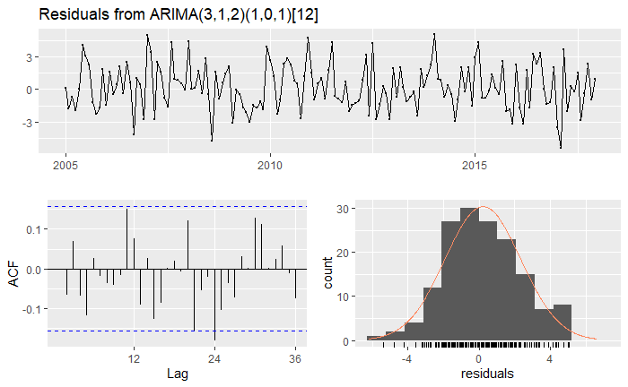

```r
print(checkresiduals(train8))
```

The above plots show that the series is still not stationary. Checking for stationary by using ADF test and visuals

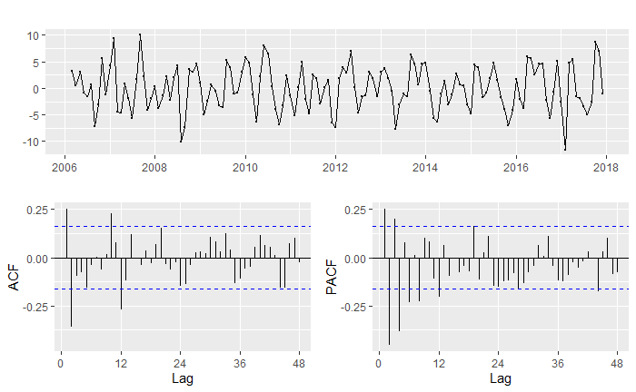

```r
PG.tr  %>% diff(2) %>% diff(lag = 12) %>% ggtsdisplay(lag=48)
```

```r
d <- PG.tr  %>% diff(2) %>% diff(lag = 12)
adf.test(d, alternative = 'stationary', k =12)
```

```
    Augmented Dickey-Fuller Test

data:  d
Dickey-Fuller = -4.0218, Lag order = 12, p-value = 0.01022
alternative hypothesis: stationary
```

Fitting the new model (3,1,2) (1,1,1)

```r
train8 <-  PG.tr %>% Arima(order= c(3,1,2), seasonal= c(1,1,1))
print("following are the residuals from the given model")
```

```
[1] "following are the residuals from the given model"
```

```
    Ljung-Box test

data:  Residuals from ARIMA(3,1,2)(1,1,1)[12]
Q* = 24.566, df = 17, p-value = 0.1049

Model df: 7.   Total lags used: 24


    Ljung-Box test

data:  Residuals from ARIMA(3,1,2)(1,1,1)[12]
Q* = 24.566, df = 17, p-value = 0.1049
```

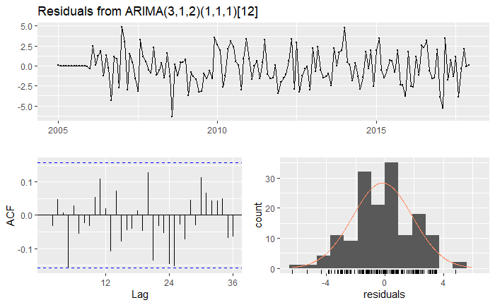

```r
print(checkresiduals(train8))
```

```r
forecast_train <- forecast(train8,h=72)
print("Following is the forecast")
```

```
[1] "Following is the forecast"
```

```r
print(forecast_train)
```

|  | Point Forecast | Lo 80 | Hi 80 | Lo 95 | Hi 95 |
| --- | --- | --- | --- | --- | --- |
| Jan 2018 | 106.12807 | 103.23211 | 109.02403 | 101.69908 | 110.55705 |
| Feb 2018 | 99.13318 | 95.62682 | 102.63954 | 93.77067 | 104.49569 |
| Mar 2018 | 94.46463 | 90.82214 | 98.10712 | 88.89393 | 100.03533 |
| Apr 2018 | 88.29767 | 84.64367 | 91.95166 | 82.70936 | 93.88597 |
| May 2018 | 93.76738 | 90.11132 | 97.42344 | 88.17592 | 99.35884 |
| Jun 2018 | 107.55793 | 103.90232 | 111.21355 | 101.96715 | 113.14871 |
| Jul 2018 | 118.00374 | 114.34787 | 121.65962 | 112.41256 | 123.59492 |
| Aug 2018 | 117.61335 | 113.95794 | 121.26876 | 112.02288 | 123.20382 |
| Sep 2018 | 105.17450 | 101.51843 | 108.83058 | 99.58302 | 110.76599 |
| Oct 2018 | 93.57466 | 89.91872 | 97.23060 | 87.98338 | 99.16594 |

[output cut: 62 more lines]

```r
NA
```

- Overlay the available data for 2018 over the forecast. Comment on the model fit and validity.

Plotting the forecast and checking it with the test dataset

[figure not shown]

```r
forecast_train <- forecast(train8,h=12)
autoplot(forecast_train)+
autolayer(PG.te)
```

```r
print("Following are the accuracies of the model ")
```

```
[1] "Following are the accuracies of the model "
```

```r
print(accuracy(forecast_train, PG.te))
```

```
                    ME     RMSE      MAE       MPE     MAPE      MASE         ACF1 Theil's U
Training set 0.2068147 2.136313 1.733317 0.1530467 1.699104 0.6404429 -0.003116301        NA
Test set     2.6784934 3.612588 3.218740 2.3777417 2.938123 1.1892914  0.217241802 0.3272631
```

The Mape and MASE are not that different from each other. Also, by looking at the visualisation, one can say the model is performing better, with less forecasting bias

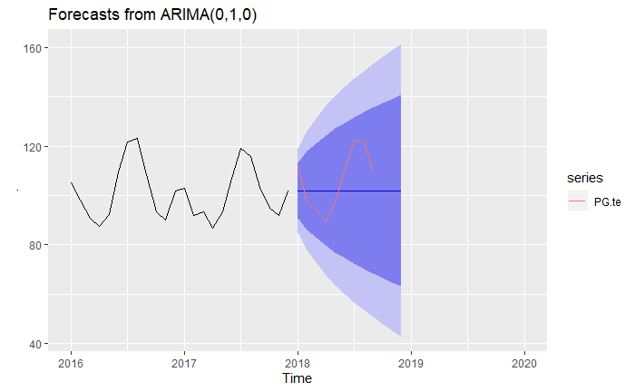

```r
train8 <-  PG.tr %>% Arima(order= c(0,1,0), seasonal= c(0,0,0))


forecast_train <- forecast(train8,h=12)
autoplot(forecast_train)+
autolayer(PG.te)+
  xlim(2016,2020)
```

```r
print("Following are the accuracies of the model ")
```

```
[1] "Following are the accuracies of the model "
```

```r
print(accuracy(forecast_train, PG.te))
```

```
                     ME      RMSE       MAE        MPE     MAPE     MASE      ACF1 Theil's U
Training set 0.01006935  8.710144  7.501149 -0.3544199 7.409176 2.771597 0.4410408        NA
Test set     4.03913333 12.033308 10.708733  2.6945040 9.880486 3.956767 0.6493589  1.219699
```